# Chapter 3 Homework Solutions

Ali Raisolsadat

2026-03-13

### Chapter 3 - Lecture 1

### Question 1: Monte Carlo estimation of an expectation

We want to compute
$$\mathbb{E}\left[
|Z|^{2/3} (|Z| + 1) \right]$$
where $Z \sim \mathcal{N}(0,1)$.

This expectation does not have a simple closed form, so we approximate it using Monte Carlo simulation.

If $Z_1, \dots, Z_N$ are i.i.d. standard normal samples the Monte Carlo estimator is
$$\hat{\mu}_N = \frac{1}{N} \sum_{i=1}^N
|Z_i|^{2/3} (|Z_i| + 1)$$
By the Law of Large Numbers, $\hat{\mu}_N \to \mathbb{E}[|Z|^{2/3}(|Z|+1)]$ as $N \to \infty$.

```r
set.seed(123)
N <- 1000000
Z <- rnorm(N)
g <- abs(Z)^(2/3) * (abs(Z) + 1)
estimate <- mean(g)
print(estimate)
```

```
## [1] 1.699951
```

### Question 2: Monte Carlo integration over a rectangle

We want to compute
$$\int_0^1 \int_0^2 (x
+ 2y) \ln(3x + 2y + 1) dx dy$$

Make the change of variables
$$x = u,
\quad y = 2v$$
so that $(u,v) \in [0,1]^2$.

The Jacobian determinant is $|J| = 2$ (recall second year calculus) and the integral becomes
$$\int_0^1 \int_0^1 2(u + 4v) \ln(3u + 4v + 1) du
dv$$
This can be written as an expectation
$$\mathbb{E}\left[ 2(U + 4V)\ln(3U + 4V + 1)
\right]$$
where $U, V \sim \text{Uniform}(0,1)$.

```r
N <- 1000000
U <- runif(N)
V <- runif(N)
f <- 2 * (U + 4*V) * log(3*U + 4*V + 1)
estimate <- mean(f)
print(estimate)
```

```
## [1] 7.996089
```

### Chapter 3 - Lecture 2

Let $U \sim \text{Uniform}(0,1)$. Then

$$\mathbb{E}(U^3) = \int_0^1 u^3 \, du =
\frac{1}{4}$$

$$\mathrm{Var}(U^3) = \mathbb{E}(U^6) -
\left(\mathbb{E}(U^3)\right)^2$$

Since
$$\mathbb{E}(U^6) = \int_0^1 u^6 \,
du = \frac{1}{7}$$
we get
$$\mathrm{Var}(U^3) = \frac{1}{7} -
\left(\frac{1}{4}\right)^2 = \frac{9}{112}$$

#### Required number of simulations

Let
$$\hat{\theta}_n = \frac{1}{n}
\sum_{i=1}^n U_i^3$$
be the Monte Carlo estimator of $\theta$.

By the Central Limit Theorem
$$\mathbb{P}\left( |\hat{\theta}_n - \theta| \le z_{1-\alpha/2}
\sqrt{\frac{\mathrm{Var}(U^3)}{n}} \right)
\approx 1 - \alpha$$

We want an absolute error less than $\varepsilon = 0.005$ with confidence level $1 - \alpha = 0.99$ so
$$z_{0.995} \sqrt{\frac{\mathrm{Var}(U^3)}{n}} \le \varepsilon$$

Solving for $n$
$$n \ge \frac{z_{0.995}^2 \,
\mathrm{Var}(U^3)}{\varepsilon^2}$$

```r
# given theoretical quantities
var_u3 <- 9 / 112
epsilon <- 0.005
alpha <- 0.01

# container for messages
out <- c()

# quantile from the standard normal distribution for 99% confidence
z <- qnorm(1 - alpha / 2)

# required number of Monte Carlo simulations
n_required <- ceiling(z^2 * var_u3 / epsilon^2)
out <- c(out, "Required number of simulations (n):")
out <- c(out, as.character(as.integer(n_required)))
out <- c(out, strrep("-", 50))

# generate samples
n <- as.integer(n_required)
U <- runif(n)

# estimator
theta_hat <- mean(U^3)
theta_exact <- 1 / 4
abs_error <- abs(theta_hat - theta_exact)
out <- c(out, sprintf("Monte Carlo estimate of theta:%.6f", theta_hat))
out <- c(out, sprintf("Exact value of theta:%.6f", theta_exact))
out <- c(out, sprintf("Absolute error: %.6f", abs_error))
out <- c(out, strrep("-", 50))

# standard error
std_error <- sqrt(var_u3 / n)

# confidence interval
ci <- c(theta_hat - z * std_error, theta_hat + z * std_error)
out <- c(out, "99% Confidence interval for theta:")
out <- c(out, sprintf("(%.6f, %.6f)", ci[1], ci[2]))

# print everything at once
cat(paste(out, collapse = "\n"))
```

```
## Required number of simulations (n):
## 21327
## --------------------------------------------------
## Monte Carlo estimate of theta:0.251532
## Exact value of theta:0.250000
## Absolute error: 0.001532
## --------------------------------------------------
## 99% Confidence interval for theta:
## (0.246532, 0.256532)
```

### Chapter 3 - Lecture 3

### Monte Carlo Estimation using Antithetic Variates

We want to estimate $\theta = \mathbb{E}(e^{1+Z})$ where $Z \sim \mathcal{N}(0,1)$.

Since the moment-generating function of a standard normal random variable is
$$\mathbb{E}(e^{tZ}) = e^{t^2/2}$$
we have
$$\theta = e \mathbb{E}(e^{Z}) = e \cdot e^{1/2} = e^{3/2}$$

```r
# exact value of the expectation
theta_exact <- exp(1.5)

cat(sprintf("Exact value of theta: %.6f\n", theta_exact))
```

```
## Exact value of theta: 4.481689
```

Let $Z_1, \dots, Z_n$ be i.i.d. standard normal random variables. The Monte Carlo estimator is
$$\hat{\theta}_{MC} = \frac{1}{n} \sum_{i=1}^n e^{1 + Z_i}$$

By the Central Limit Theorem, a 95% confidence interval is
$$\hat{\theta}_{MC} \pm 1.96 \frac{s}{\sqrt{n}}$$
where $s^2$ is the sample variance.

```r
n <- 200000
Z <- rnorm(n)
g <- exp(1 + Z)
theta_mc <- mean(g)
std_error_mc <- sd(g) / sqrt(n)
ci_mc <- c(theta_mc - 1.96 * std_error_mc,
           theta_mc + 1.96 * std_error_mc)

# print everything at once
out <- c(sprintf("Monte Carlo estimate of theta: %.6f", theta_mc))
out <- c(out, sprintf("Monte Carlo variance of theta: %.6f", var(g)))
out <- c(out, sprintf("Exact value of theta: %.6f", theta_exact))
out <- c(out, "99% Confidence interval for theta:")
out <- c(out, sprintf("[%.6f, %.6f]\n", ci_mc[1], ci_mc[2]))
cat(paste(out, collapse = "\n"))
```

```
## Monte Carlo estimate of theta: 4.466417
## Monte Carlo variance of theta: 33.245467
## Exact value of theta: 4.481689
## 99% Confidence interval for theta:
## [4.441147, 4.491687]
```

For each $Z_i \sim \mathcal{N}(0,1)$, define the antithetic variable $Z_i' = -Z_i$ The antithetic estimator is
$$\hat{\theta}_{AV} = \frac{1}{n} \sum_{i=1}^n \frac{1}{2}\left(e^{1+Z_i}
+ e^{1-Z_i}\right)$$
$e^{1+Z}$ is monotone in $Z$, the pair $(Z, -Z)$ is negatively correlated leading to variance reduction.

```r
n <- 200000
Z <- rnorm(n)
g_av <- 0.5 * (exp(1 + Z) + exp(1 - Z))
theta_av <- mean(g_av)
std_error_av <- sd(g_av) / sqrt(n)
ci_av <- c(theta_av - 1.96 * std_error_av,
           theta_av + 1.96 * std_error_av)

# print everything at once
out <- c(sprintf("Monte Carlo estimate of theta: %.6f", theta_av))
out <- c(out, sprintf("Monte Carlo variance of theta: %.6f", var(g_av)))
out <- c(out, sprintf("Exact value of theta: %.6f", theta_exact))
out <- c(out, "99% Confidence interval for theta:")
out <- c(out, sprintf("[%.6f, %.6f]\n", ci_av[1], ci_av[2]))
cat(paste(out, collapse = "\n"))
```

```
## Monte Carlo estimate of theta: 4.484631
## Monte Carlo variance of theta: 10.718000
## Exact value of theta: 4.481689
## 99% Confidence interval for theta:
## [4.470282, 4.498979]
```

### Chapter 3 - Lecture 4

Let $X_1, \dots, X_n \sim \mathcal{N}(0,1)$. The basic Monte Carlo estimator is
$$\hat{p}_{MC} = \frac{1}{n} \sum_{i=1}^n \mathbf{1}_A(X_i)$$

This estimator is unbiased but inefficient for rare events since most samples fall outside the interval $[3,4]$.

```r
n <- 1000000
X <- rnorm(n)

# exact value of the probability
p_exact <- pnorm(4) - pnorm(3)
cat(sprintf("Exact value: %.6f\n", p_exact))
```

```
## Exact value: 0.001318
```

```r
indicators <- as.numeric(X >= 3 & X <= 4)
p_hat_mc <- mean(indicators)
std_error_mc <- sqrt(p_hat_mc * (1 - p_hat_mc) / n)
ci_mc <- c(p_hat_mc - 1.96 * std_error_mc,
           p_hat_mc + 1.96 * std_error_mc)

# print everything at once
out <- c(sprintf("Monte Carlo estimate of p: %.6f", p_hat_mc))
out <- c(out, "99% Confidence interval for p:")
out <- c(out, sprintf("[%.6f, %.6f]\n", ci_mc[1], ci_mc[2]))
cat(paste(out, collapse = "\n"))
```

```
## Monte Carlo estimate of p: 0.001250
## 99% Confidence interval for p:
## [0.001181, 0.001319]
```

We generate samples from the proposal density $h(x) = \mathcal{N}(3.5, 1)$

Using importance sampling
$$P(X \in A) =
\mathbb{E}_h\left[\mathbf{1}_A(Y)\,\frac{f(Y)}{h(Y)} \right]$$
where $f$ is the $\mathcal{N}(0,1)$ density and $Y \sim h$.

This shifts probability mass into the rare-event region $[3,4]$ reducing variance.

```r
Y <- rnorm(n, mean = 3.5, sd = 1.0)

# target density f and proposal density h
f <- dnorm(Y, mean = 0, sd = 1)
h <- dnorm(Y, mean = 3.5, sd = 1)

weights <- f / h

is_estimates <- weights * as.numeric(Y >= 3 & Y <= 4)

p_hat_is <- mean(is_estimates)

std_error_is <- sd(is_estimates) / sqrt(n)

ci_is <- c(p_hat_is - 1.96 * std_error_is,
           p_hat_is + 1.96 * std_error_is)

# print everything at once
out <- c(sprintf("Exact value: %.6f", p_exact))
out <- c(out, sprintf("Importance sampling estimate of p: %.6f", p_hat_is))
out <- c(out, "99% Confidence interval for p:")
out <- c(out, sprintf("[%.6f, %.6f]\n", ci_is[1], ci_is[2]))
cat(paste(out, collapse = "\n"))
```

```
## Exact value: 0.001318
## Importance sampling estimate of p: 0.001320
## 99% Confidence interval for p:
## [0.001315, 0.001325]
```

### Chapter 3 - Lecture 5

Let $U \sim \text{Uniform}(0,1)$ and $g(x) = e^x$. We want to estimate $\theta = \mathbb{E}(g(U))$.

The exact value is
$$\theta =
\mathbb{E}(e^U) = \int_0^1 e^x \, dx = e - 1$$

Let $U_1, \dots, U_n \sim \text{Uniform}(0,1)$. The basic Monte Carlo estimator is
$$\hat{\theta}_{MC} = \frac{1}{n} \sum_{i=1}^n
e^{U_i}$$

```r
n <- 200000
U <- runif(n)

# exact value
theta_exact <- exp(1) - 1
cat(sprintf("Exact value of theta: %.6f\n", theta_exact))
```

```
## Exact value of theta: 1.718282
```

```r
# Monte Carlo estimation
g <- exp(U)
theta_mc <- mean(g)
std_error_mc <- sd(g) / sqrt(n)
ci_mc <- c(theta_mc - 1.96 * std_error_mc,
           theta_mc + 1.96 * std_error_mc)

# print everything at once
out <- c(sprintf("Monte Carlo estimate of theta: %.6f", theta_mc))
out <- c(out, sprintf("Monte Carlo variance of theta: %.6f", var(g)))
out <- c(out, "99% Confidence interval for theta:")
out <- c(out, sprintf("[%.6f, %.6f]\n", ci_mc[1], ci_mc[2]))
cat(paste(out, collapse = "\n"))
```

```
## Monte Carlo estimate of theta: 1.716882
## Monte Carlo variance of theta: 0.241917
## 99% Confidence interval for theta:
## [1.714726, 1.719037]
```

Let the control variate be
$$h(U) = U
\quad \mathbb{E}(h(U)) = \frac{1}{2}$$

The control variates estimator is
$$\hat{\theta}_{CV} = \frac{1}{n} \sum_{i=1}^n
\left[g(U_i) - c\big(h(U_i) - \mathbb{E}(h(U))\big)\right]$$

The optimal coefficient is
$$c_0 =
\frac{\mathrm{Cov}(g(U), h(U))}{\mathrm{Var}(h(U))}$$

Compute
$$\mathrm{Cov}(e^U, U) =
\mathbb{E}(Ue^U) - \mathbb{E}(e^U)\mathbb{E}(U)$$
$$\mathbb{E}(Ue^U) = \int_0^1 u e^u \, du =
1$$

So
$$\mathrm{Cov}(e^U, U) = 1 -
\frac{e-1}{2} = \frac{3 - e}{2} \quad \mathrm{Var}(U) =
\frac{1}{12}$$

and
$$c_0 = 6(3 - e)$$

```r
c0 = 6 * (3 - exp(1))
sprintf("Efficient coefficient: %.6f", c0)
```

```
## [1] "Efficient coefficient: 1.690309"
```

```r
h <- U
Eh <- 0.5
Y <- g - c0 * (h - Eh)
theta_cv <- mean(Y)
std_error_cv <- sd(g - Y) / sqrt(n)
ci_cv <- c(theta_cv - 1.96 * std_error_cv,
           theta_cv + 1.96 * std_error_cv)

# print everything at once
out <- c(sprintf("Control variate estimate of theta: %.6f", theta_cv))
out <- c(out, sprintf("Control variate variance of theta: %.6f", var(Y)))
out <- c(out, "99% Confidence interval for theta:")
out <- c(out, sprintf("[%.6f, %.6f]\n", ci_cv[1], ci_cv[2]))
cat(paste(out, collapse = "\n"))
```

```
## Control variate estimate of theta: 1.718290
## Control variate variance of theta: 0.003939
## 99% Confidence interval for theta:
## [1.716152, 1.720429]
```

We compare the empirical variances of the Monte Carlo estimators.

```r
var_mc <- var(g)
var_cv <- var(g - c0 * (h - Eh))
empirical_factor <- var_cv / var_mc
cat(sprintf("Empirical ratio of the variances: %.6f\n", empirical_factor))
```

```
## Empirical ratio of the variances: 0.016283
```

The theoretical variance reduction factor is
$$1 - \rho^2(g(U), h(U))$$
where $\rho$ is the correlation coefficient.

```r
rho <- cor(g, h)
theoretical_factor <- 1 - rho^2
cat(sprintf("Empirical ratio of the variances: %.6f\n", empirical_factor))
```

```
## Empirical ratio of the variances: 0.016283
```

```r
cat(sprintf("Theoretical ratio of the variances: %.6f\n", theoretical_factor))
```

```
## Theoretical ratio of the variances: 0.016283
```

### Chapter 3 - Lecture 6

Let $X_1,\dots,X_9$ be i.i.d. samples from an exponential distribution with mean $\mu \in [3,5]$ (rate $\lambda = 1/\mu$).

We only observe the minimum, median and maximum. We use the estimator
$$\hat{\theta}(X) = \frac{2\min(X) + \text{median}(X) + \max(X)}{4}$$

Our goals are: 1. Estimate the bias of $\hat{\theta}$ for $\mu \in [3,5]$ using Monte Carlo simulation. 2. Propose a bias-corrected estimator
$$\hat{\theta}_1(X) = \hat{\theta}(X) + C$$
with smaller bias over this interval.

```r
N <- 1000
sample_size <- 9
mu_values <- seq(3, 5, length.out = sample_size)
biases <- numeric(length(mu_values))

for (i in seq_along(mu_values)) {
  mu <- mu_values[i]
  estimates <- numeric(N)

  for (j in 1:N) {
    X <- rexp(sample_size, rate = 1 / mu)  # exponential with mean mu
    X_sorted <- sort(X)
    estimator <- (2 * X_sorted[1] + X_sorted[5] + X_sorted[sample_size]) / 4
    estimates[j] <- estimator
  }

  biases[i] <- mean(estimates) - mu
}

print(biases)
```

```
## [1] -0.1513709 -0.1194718 -0.1866210 -0.1736130 -0.2163741 -0.2074654 -0.2294062
## [8] -0.2877606 -0.3207843
```

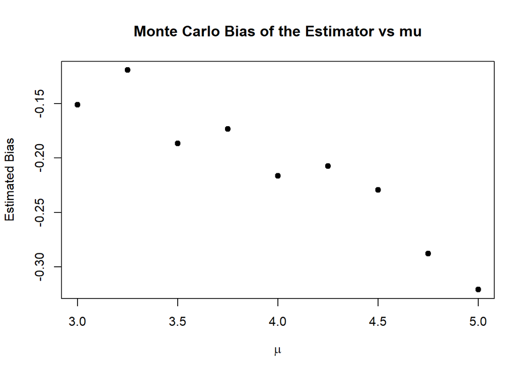

```r
# scatter plot of bias vs mu
plot(mu_values, biases,xlab = expression(mu),ylab = "Estimated Bias",main = "Monte Carlo Bias of the Estimator vs mu",pch = 19)
```

```r
avg_bias = mean(biases)
sprintf("Average of Biases: %.6f", avg_bias)
```

```
## [1] "Average of Biases: -0.210319"
```

Based on the simulation, we define the corrected estimator
$$\hat{\theta}_1(X) = \hat{\theta}(X) -
\bar{b}$$
where $\bar{b}$ is the average Monte Carlo bias over $[3,5]$.

This choice minimizes the bias **on average** over the interval.

```r
corrected_biases <- numeric(length(mu_values))

for (i in seq_along(mu_values)) {
  mu <- mu_values[i]
  estimates <- numeric(N)

  for (j in 1:N) {
    X <- rexp(sample_size, rate = 1 / mu)  # exponential with mean mu
    X_sorted <- sort(X)

    estimator <- (2 * X_sorted[1] + X_sorted[5] + X_sorted[sample_size]) / 4
    estimator_corrected <- estimator - avg_bias  # avg_bias must be defined previously
    estimates[j] <- estimator_corrected
  }

  corrected_biases[i] <- mean(estimates) - mu
}

print(corrected_biases)
```

```
## [1]  0.09409520 -0.01027227  0.04311631  0.06229094  0.01692912  0.02270983
## [7]  0.04333601 -0.08383674 -0.08704285
```

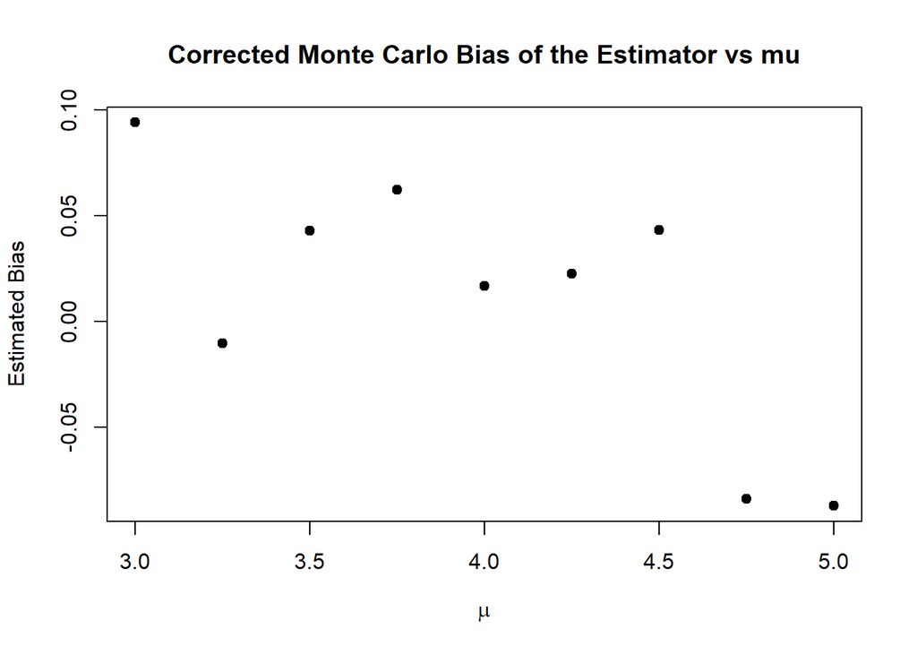

```r
# scatter plot of corrected bias vs mu
plot(mu_values, corrected_biases,
     xlab = expression(mu), ylab = "Estimated Bias",
     main = "Corrected Monte Carlo Bias of the Estimator vs mu",pch = 19)
```

### Chapter 3 - Lecture 6

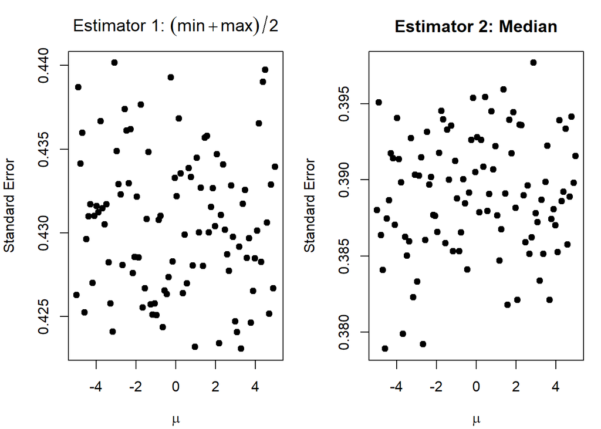

```r
N <- 5000  # Monte Carlo repetitions
n <- 10    # sample size
mu_values <- seq(-5, 5, length.out = 100)

se_mu1 <- numeric(length(mu_values))
se_mu2 <- numeric(length(mu_values))

for (i in seq_along(mu_values)) {
  mu <- mu_values[i]
  est1 <- numeric(N)
  est2 <- numeric(N)

  for (j in 1:N) {
    X <- rnorm(n, mean = mu, sd = 1)
    X_sorted <- sort(X)
    mu1 <- 0.5 * (X_sorted[1] + X_sorted[n])
    mu2 <- X_sorted[n %/% 2]  # median for n=10
    est1[j] <- mu1
    est2[j] <- mu2
  }

  se_mu1[i] <- sd(est1)
  se_mu2[i] <- sd(est2)
}

# plotting
par(mfrow = c(1, 2), mar = c(4, 4, 3, 1))

# estimator 1
plot(mu_values, se_mu1, pch = 19,
     xlab = expression(mu), ylab = "Standard Error",
     main = expression("Estimator 1: " * (min + max)/2))

# estimator 2
plot(mu_values, se_mu2, pch = 19,
     xlab = expression(mu), ylab = "Standard Error",
     main = "Estimator 2: Median")
```

### Chapter 3 - Lecture 7

#### Loop version

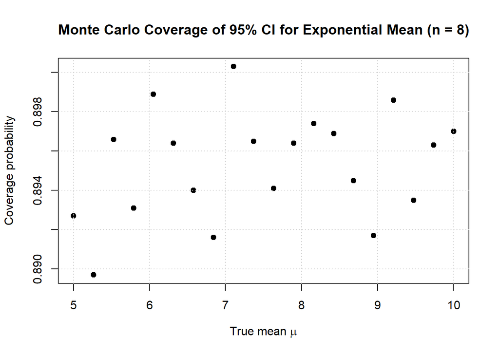

```r
n <- 8               # sample size
N <- 10000           # Monte Carlo replications
alpha <- 0.05
mu_grid <- seq(5, 10, length.out = 20)
t_crit <- qt(1 - alpha/2, df = n - 1)
coverage_loop <- numeric(length(mu_grid))

for (i in seq_along(mu_grid)) {
  mu <- mu_grid[i]
  count <- 0

  for (j in 1:N) {
    # generate sample
    X <- rexp(n, rate = 1 / mu)  # mean = mu

    # sample statistics
    Xbar <- mean(X)
    s <- sd(X)

    # confidence interval
    d <- t_crit * s / sqrt(n)
    U <- Xbar - d
    V <- Xbar + d

    # coverage check
    if (U <= mu && mu <= V) {
      count <- count + 1
    }
  }

  coverage_loop[i] <- count / N
}

# plot
plot(mu_grid, coverage_loop, pch = 19,
     xlab = expression("True mean " * mu), ylab = "Coverage probability",
     main = "Monte Carlo Coverage of 95% CI for Exponential Mean (n = 8)")
grid()
```

#### Vectorized version

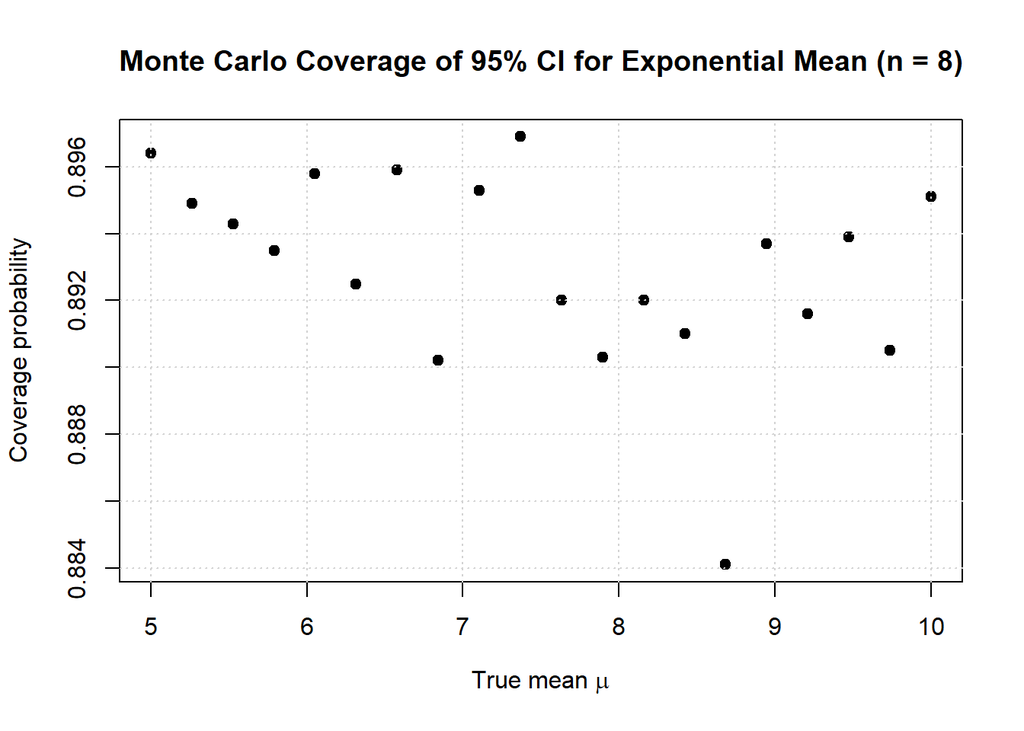

```r
coverage_matrix <- numeric(length(mu_grid))

for (i in seq_along(mu_grid)) {
  mu <- mu_grid[i]

  # generate all samples at once
  X <- matrix(rexp(N * n, rate = 1 / mu), nrow = N, ncol = n)

  # sample statistics (along rows)
  Xbar <- rowMeans(X)
  s <- apply(X, 1, sd)

  # confidence intervals
  d <- t_crit * s / sqrt(n)
  U <- Xbar - d
  V <- Xbar + d

  # Coverage indicator
  coverage <- mean(U <= mu & mu <= V)
  coverage_matrix[i] <- coverage
}

plot(mu_grid, coverage_matrix, pch = 19,
     xlab = expression("True mean " * mu), ylab = "Coverage probability",
     main = "Monte Carlo Coverage of 95% CI for Exponential Mean (n = 8)")
grid()
```

#### Runtime Comparison

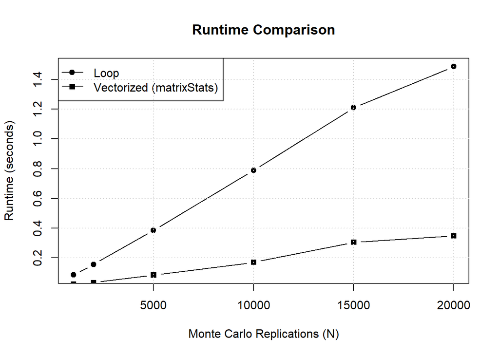

```r
library(matrixStats) # we need this package to use power of Fortran

coverage_fast <- function(mu_grid, n, N, alpha = 0.05) {
  t_crit <- qt(1 - alpha/2, df = n - 1)
  coverage <- numeric(length(mu_grid))

  for (i in seq_along(mu_grid)) {
    mu <- mu_grid[i]
    # generate all samples at once
    X <- matrix(rexp(N * n, rate = 1 / mu), nrow = N, ncol = n)
    # fast row statistics
    Xbar <- rowMeans(X)
    s <- rowSds(X)
    d <- t_crit * s / sqrt(n)
    coverage[i] <- mean((Xbar - d <= mu) & (mu <= Xbar + d))
  }
  return(coverage)
}

coverage_loop <- function(mu_grid, n, N, alpha = 0.05) {
  t_crit <- qt(1 - alpha/2, df = n - 1)
  coverage <- numeric(length(mu_grid))

  for (i in seq_along(mu_grid)) {
    mu <- mu_grid[i]
    k <- 0

    for (j in 1:N) {
      X <- rexp(n, rate = 1 / mu)
      Xbar <- mean(X)
      s <- sd(X)
      d <- t_crit * s / sqrt(n)

      if (Xbar - d <= mu && mu <= Xbar + d) {
        k <- k + 1
      }
    }
    coverage[i] <- k / N
  }
  coverage
}

set.seed(123)
n <- 100
mu_grid <- seq(5, 10, length.out = 6)
N_values <- c(1000,2000,5000,10000,15000,20000)
times_loop <- numeric(length(N_values))
times_fast <- numeric(length(N_values))

# time the calculations
for (i in seq_along(N_values)) {
  N <- N_values[i]
  start <- Sys.time()
  coverage_loop(mu_grid, n, N)
  times_loop[i] <- as.numeric(Sys.time() - start)

  start <- Sys.time()
  coverage_fast(mu_grid, n, N)
  times_fast[i] <- as.numeric(Sys.time() - start)
}

# plot
plot(N_values, times_loop, type="b", pch=19,
     xlab="Monte Carlo Replications (N)",
     ylab="Runtime (seconds)",
     main="Runtime Comparison")
lines(N_values, times_fast, type="b", pch=15)
legend("topleft",
       legend=c("Loop","Vectorized (matrixStats)"),
       pch=c(19,15),
       lty=1)
grid()
```